# Constraining Curve Parameters

Zachery Moore

22 October 2026

# 1 Objective

The `dosefitr` package provides tools for fitting curves to data. This vignette walks through the main functionality of setting bounds on individual curve parameters.

```r
library(dosefitr)
```

# 2 Constraining curve parameters

By default, `fit_curve()` estimates every model parameter freely from the data. Sometimes you know more about the system than the data alone can tell the model, for example that a readout cannot exceed a physical maximum. In these cases you can place bounds on individual parameters.

To illustrate, we use the built-in `iris` dataset. Petal width and petal length aren’t a growth curve, but their relationship has a saturating shape that makes a convenient example. We first express each measurement as a percentage of its maximum, so both variables run from 0 to 100.

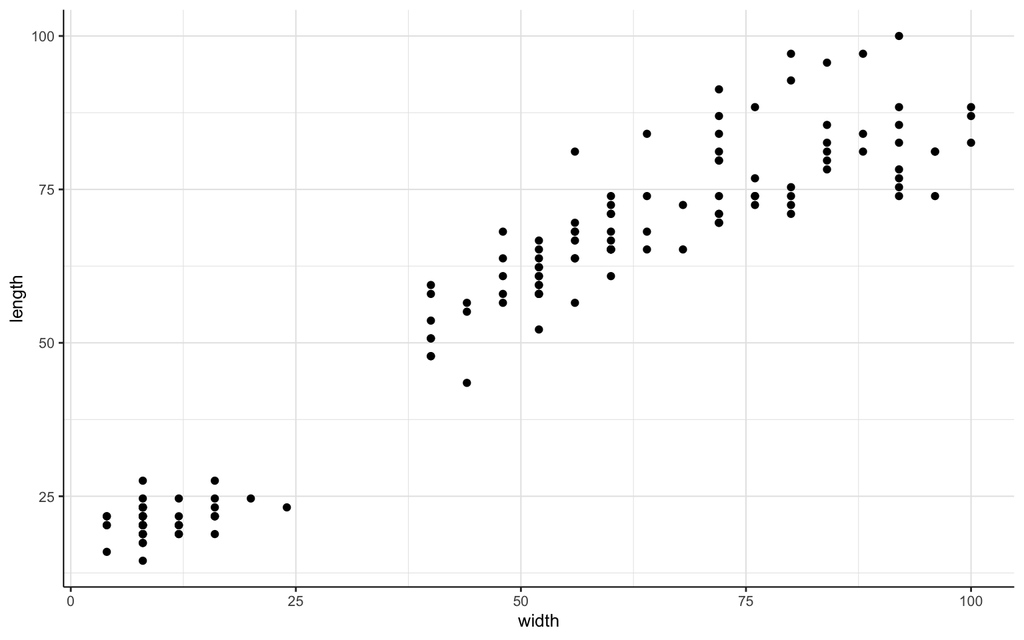

```r
iris_percent <- data.frame(
  width = iris$Petal.Width / max(iris$Petal.Width) * 100,
  length = iris$Petal.Length / max(iris$Petal.Length) * 100
)

ggplot2::ggplot(iris_percent, ggplot2::aes(x = width, y = length)) +
  ggplot2::geom_point() +
  theme_dosefitr()
```

## 2.1 Unconstrained fit

We start by fitting a four-parameter sigmoid with no constraints.

```r
iris_model <- fit_curve(
  data = iris_percent,
  x_var = "width",
  y_var = "length",
  curve_options = list(model = "four_param_sigmoid")
)

iris_model$curve$nls_model
```

```
## Nonlinear regression model
##   model: y ~ f(x, top, bottom, ec50, slope)
##    data: data
## bottom    top   ec50  slope
## 19.930 92.611 45.975  2.785
##  residual sum-of-squares: 4458
##
## Number of iterations to convergence: 8
## Achieved convergence tolerance: 1.49e-08
```

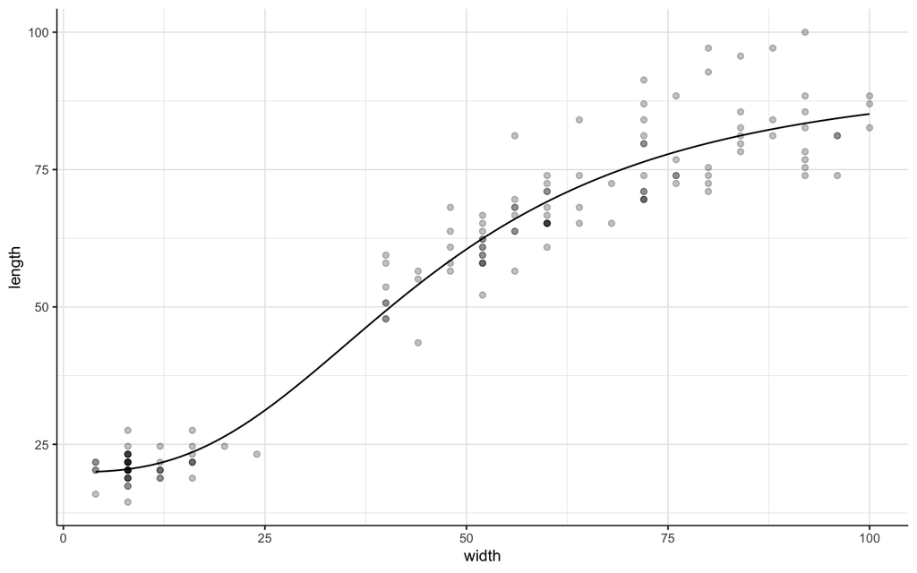

```r
plot_model(
  list = iris_model,
  x_var = "width",
  y_var = "length"
)
```

## 2.2 Bounding a parameter

Bounds are passed through `curve_options` as named lists, `upper_bounds` and `lower_bounds`, where each name matches a model parameter. Because length is expressed as a percentage of its maximum, the curve should not plateau above 100. However, we can cap the top at 80.

```r
iris_model_bounded <- fit_curve(
  data = iris_percent,
  x_var = "width",
  y_var = "length",
  curve_options = list(
    model = "four_param_sigmoid",
    upper_bounds = list(top = 80)
  )
)

iris_model_bounded$curve$nls_model
```

```
## Nonlinear regression model
##   model: y ~ f(x, top, bottom, ec50, slope)
##    data: data
## bottom    top   ec50  slope
## 21.010 80.000 41.684  4.503
##  residual sum-of-squares: 5315
##
## Number of iterations to convergence: 12
## Achieved convergence tolerance: 1.49e-08
```

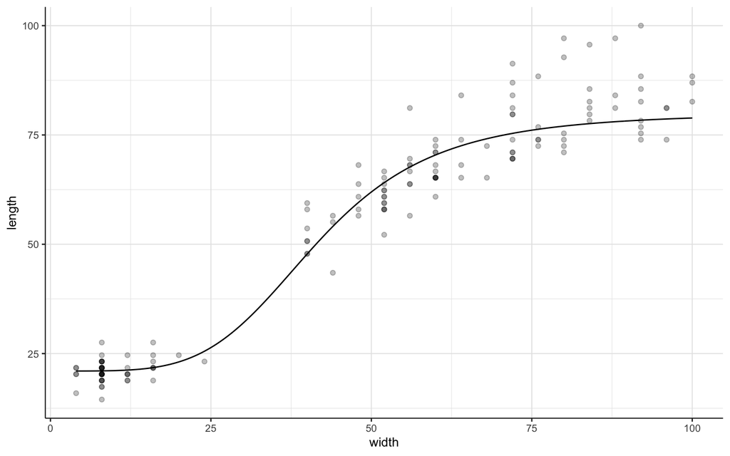

```r
plot_model(
  list = iris_model_bounded,
  x_var = "width",
  y_var = "length"
)
```

Comparing the parameter estimates with the unconstrained fit, `top` is now held at or below 80, and the remaining parameters adjust to compensate. `lower_bounds` works the same way, for example `lower_bounds = list(bottom = 25)` to stop the lower plateau falling below 25.

## 2.3 Combining bounds with outlier handling

```r
iris_model_bounded_outlier <- fit_curve(
  data = iris_percent,
  x_var = "width",
  y_var = "length",
  curve_options = list(
    model = "four_param_sigmoid",
    upper_bounds = list(top = 80)
  ),
  outlier_options = list(huber = TRUE, rout = TRUE)
)

iris_model_bounded_outlier$curve$nls_model
```

```
## Nonlinear regression model
##   model: y ~ f(x, top, bottom, ec50, slope)
##    data: data
## bottom    top   ec50  slope
## 20.877 80.000 41.265  4.192
##  residual sum-of-squares: 3722
##
## Number of iterations to convergence: 9
## Achieved convergence tolerance: 1.49e-08
```

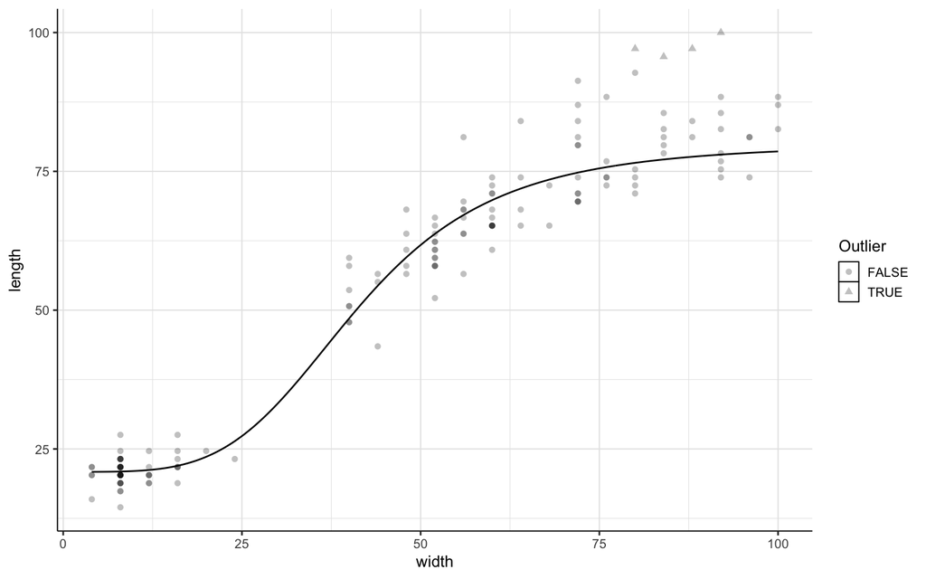

```r
plot_model(
  list = iris_model_bounded_outlier,
  x_var = "width",
  y_var = "length"
)
```